# SymPy

`SymPy` - это пакет для символьных вычислений на питоне, подобный системе *Mathematica*. Он работает с выражениями, содержащими символы.

```python
from sympy import *
init_printing()
```

Основными кирпичиками, из которых строятся выражения, являются символы. Символ имеет имя, которое используется при печати выражений. Объекты класса `Symbol` нужно создавать и присваивать переменным питона, чтобы их можно было использовать. В принципе, имя символа и имя переменной, которой мы присваиваем этот символ - две независимые вещи, и можно написать `abc=Symbol('xyz')`. Но тогда при вводе программы Вы будете использовать `abc`, а при печати результатов `SymPy` будет использовать `xyz`, что приведёт к ненужной путанице. Поэтому лучше, чтобы имя символа совпадало с именем переменной питона, которой он присваивается.

В языках, специально предназначенных для символьных вычислений, таких, как *Mathematica*, если Вы используете переменную, которой ничего не было присвоено, то она автоматически воспринимается как символ с тем же именем. Питон не был изначально предназначен для символьных вычислений. Если Вы используете переменную, которой ничего не было присвоено, Вы получите сообщение об ошибке. Объекты типа `Symbol` нужно создавать явно.

```python
x=Symbol('x')
```

```python
a=x**2-1
a
```

$$x^{2} - 1$$

```python
type(a)
```

```
sympy.core.add.Add
```

Можно определить несколько символов одновременно. Строка разбивается на имена по пробелам.

```python
y,z=symbols('y z')
```

Подставим вместо $x$ выражение $y+1$.

```python
a.subs(x,y+1)
```

$$\left(y + 1\right)^{2} - 1$$

## Многочлены и рациональные функции

`SymPy` не раскрывает скобки автоматически. Для этого используется функция `expand`.

```python
a=(x+y-z)**6
a
```

$$\left(x + y - z\right)^{6}$$

```python
a=expand(a)
a
```

$$x^{6} + 6 x^{5} y - 6 x^{5} z + 15 x^{4} y^{2} - 30 x^{4} y z + 15 x^{4} z^{2} + 20 x^{3} y^{3} - 60 x^{3} y^{2} z + 60 x^{3} y z^{2} - 20 x^{3} z^{3} + 15 x^{2} y^{4} - 60 x^{2} y^{3} z + 90 x^{2} y^{2} z^{2} - 60 x^{2} y z^{3} + 15 x^{2} z^{4} + 6 x y^{5} - 30 x y^{4} z + 60 x y^{3} z^{2} - 60 x y^{2} z^{3} + 30 x y z^{4} - 6 x z^{5} + y^{6} - 6 y^{5} z + 15 y^{4} z^{2} - 20 y^{3} z^{3} + 15 y^{2} z^{4} - 6 y z^{5} + z^{6}$$

Степень многочлена $a$ по $x$.

```python
degree(a,x)
```

$$6$$

Соберём вместе члены с определёнными степенями $x$.

```python
collect(a,x)
```

$$x^{6} + x^{5} \left(6 y - 6 z\right) + x^{4} \left(15 y^{2} - 30 y z + 15 z^{2}\right) + x^{3} \left(20 y^{3} - 60 y^{2} z + 60 y z^{2} - 20 z^{3}\right) + x^{2} \left(15 y^{4} - 60 y^{3} z + 90 y^{2} z^{2} - 60 y z^{3} + 15 z^{4}\right) + x \left(6 y^{5} - 30 y^{4} z + 60 y^{3} z^{2} - 60 y^{2} z^{3} + 30 y z^{4} - 6 z^{5}\right) + y^{6} - 6 y^{5} z + 15 y^{4} z^{2} - 20 y^{3} z^{3} + 15 y^{2} z^{4} - 6 y z^{5} + z^{6}$$

Многочлен с целыми коэффициентами можно записать в виде произведения таких многочленов (причём каждый сомножитель уже невозможно расфакторизовать дальше, оставаясь в рамках многочленов с целыми коэффициентами). Существуют эффективные алгоритмы для решения этой задачи.

```python
a=factor(a)
a
```

$$\left(x + y - z\right)^{6}$$

`SymPy` не сокращает отношения многочленов на их наибольший общий делитель автоматически. Для этого используется функция `cancel`.

```python
a=(x**3-y**3)/(x**2-y**2)
a
```

$$\frac{x^{3} - y^{3}}{x^{2} - y^{2}}$$

```python
cancel(a)
```

$$\frac{x^{2} + x y + y^{2}}{x + y}$$

`SymPy` не приводит суммы рациональных выражений к общему знаменателю автоматически. Для этого используется функция `together`.

```python
a=y/(x-y)+x/(x+y)
a
```

$$\frac{x}{x + y} + \frac{y}{x - y}$$

```python
together(a)
```

$$\frac{x \left(x - y\right) + y \left(x + y\right)}{\left(x - y\right) \left(x + y\right)}$$

Функция `simplify` пытается переписать выражение *в наиболее простом виде*. Это понятие не имеет чёткого определения (в разных ситуациях *наиболее простыми* могут считаться разные формы выражения), и не существует алгоритма такого упрощения. Функция `symplify` работает эвристически, и невозможно заранее предугадать, какие упрощения она попытается сделать. Поэтому её удобно использовать в интерактивных сессиях, чтобы посмотреть, удастся ли ей записать выражение в каком-нибудь разумном виде, но нежелательно использовать в программах. В них лучше применять более специализированные функции, которые выполняют одно определённое преобразование выражения.

```python
simplify(a)
```

$$\frac{x^{2} + y^{2}}{x^{2} - y^{2}}$$

Разложение на элементарные дроби по отношению к $x$ и $y$.

```python
apart(a,x)
```

$$- \frac{y}{x + y} + \frac{y}{x - y} + 1$$

```python
apart(a,y)
```

$$\frac{x}{x + y} + \frac{x}{x - y} - 1$$

Подставим конкретные численные значения вместо переменных $x$ и $y$.

```python
a=a.subs({x:1,y:2})
a
```

$$- \frac{5}{3}$$

А сколько это будет численно?

```python
a.n()
```

$$-1.66666666666667$$

## Элементарные функции

`SymPy` автоматически применяет упрощения элементарных функция (которые справедливы во всех случаях).

```python
sin(-x)
```

$$- \sin{\left (x \right )}$$

```python
cos(pi/4),tan(5*pi/6)
```

$$\left ( \frac{\sqrt{2}}{2}, \quad - \frac{\sqrt{3}}{3}\right )$$

`SymPy` может работать с числами с плавающей точкой, имеющими сколь угодно большую точность. Вот $\pi$ с 100 значащими цифрами.

```python
pi.n(100)
```

$$3.141592653589793238462643383279502884197169399375105820974944592307816406286208998628034825342117068$$

`E` - это основание натуральных логарифмов.

```python
log(1),log(E)
```

$$\left ( 0, \quad 1\right )$$

```python
exp(log(x)),log(exp(x))
```

$$\left ( x, \quad \log{\left (e^{x} \right )}\right )$$

А почему не $x$? Попробуйте подставить $x=2\pi i$.

```python
sqrt(0)
```

$$0$$

```python
sqrt(x)**4,sqrt(x**4)
```

$$\left ( x^{2}, \quad \sqrt{x^{4}}\right )$$

А почему не $x^2$? Попробуйте подставить $x=i$.

Символы могут иметь некоторые свойства. Например, они могут быть положительными. Тогда `SymPy` может сильнее упростить квадратные корни.

```python
p,q=symbols('p q',positive=True)
sqrt(p**2)
```

$$p$$

```python
sqrt(12*x**2*y),sqrt(12*p**2*y)
```

$$\left ( 2 \sqrt{3} \sqrt{x^{2} y}, \quad 2 \sqrt{3} p \sqrt{y}\right )$$

Пусть символ $n$ будет целым (`I` - это мнимая единица).

```python
n=Symbol('n',integer=True)
simplify(exp(2*pi*I*n))
```

$$1$$

```python
sin(pi*n)
```

$$0$$

Метод `rewrite` пытается переписать выражение в терминах заданной функции.

```python
cos(x).rewrite(exp),exp(I*x).rewrite(cos)
```

$$\left ( \frac{e^{i x}}{2} + \frac{1}{2} e^{- i x}, \quad i \sin{\left (x \right )} + \cos{\left (x \right )}\right )$$

```python
asin(x).rewrite(log)
```

$$- i \log{\left (i x + \sqrt{- x^{2} + 1} \right )}$$

Функция `trigsimp` пытается переписать тригонометрическое выражение в *наиболее простом виде*. В программах лучше использовать более специализированные функции.

```python
trigsimp(2*sin(x)**2+3*cos(x)**2)
```

$$\cos^{2}{\left (x \right )} + 2$$

Функция `expand_trig` разлагает синусы и косинусы сумм и кратных углов.

```python
expand_trig(sin(x-y)),expand_trig(sin(2*x))
```

$$\left ( \sin{\left (x \right )} \cos{\left (y \right )} - \sin{\left (y \right )} \cos{\left (x \right )}, \quad 2 \sin{\left (x \right )} \cos{\left (x \right )}\right )$$

Чаще нужно обратное преобразование - произведений и степеней синусов и косинусов в выражения, линейные по этим функциям. Например, пусть мы работаем с отрезком ряда Фурье.

```python
a1,a2,b1,b2=symbols('a1 a2 b1 b2')
a=a1*cos(x)+a2*cos(2*x)+b1*sin(x)+b2*sin(2*x)
a
```

$$a_{1} \cos{\left (x \right )} + a_{2} \cos{\left (2 x \right )} + b_{1} \sin{\left (x \right )} + b_{2} \sin{\left (2 x \right )}$$

Мы хотим возвести его в квадрат и опять получить отрезок ряда Фурье.

```python
a=(a**2).rewrite(exp).expand().rewrite(cos).expand()
a
```

$$\frac{a_{1}^{2}}{2} \cos{\left (2 x \right )} + \frac{a_{1}^{2}}{2} + a_{1} a_{2} \cos{\left (x \right )} + a_{1} a_{2} \cos{\left (3 x \right )} + a_{1} b_{1} \sin{\left (2 x \right )} + a_{1} b_{2} \sin{\left (x \right )} + a_{1} b_{2} \sin{\left (3 x \right )} + \frac{a_{2}^{2}}{2} \cos{\left (4 x \right )} + \frac{a_{2}^{2}}{2} - a_{2} b_{1} \sin{\left (x \right )} + a_{2} b_{1} \sin{\left (3 x \right )} + a_{2} b_{2} \sin{\left (4 x \right )} - \frac{b_{1}^{2}}{2} \cos{\left (2 x \right )} + \frac{b_{1}^{2}}{2} + b_{1} b_{2} \cos{\left (x \right )} - b_{1} b_{2} \cos{\left (3 x \right )} - \frac{b_{2}^{2}}{2} \cos{\left (4 x \right )} + \frac{b_{2}^{2}}{2}$$

```python
a.collect([cos(x),cos(2*x),cos(3*x),sin(x),sin(2*x),sin(3*x)])
```

$$\frac{a_{1}^{2}}{2} + a_{1} b_{1} \sin{\left (2 x \right )} + \frac{a_{2}^{2}}{2} \cos{\left (4 x \right )} + \frac{a_{2}^{2}}{2} + a_{2} b_{2} \sin{\left (4 x \right )} + \frac{b_{1}^{2}}{2} - \frac{b_{2}^{2}}{2} \cos{\left (4 x \right )} + \frac{b_{2}^{2}}{2} + \left(\frac{a_{1}^{2}}{2} - \frac{b_{1}^{2}}{2}\right) \cos{\left (2 x \right )} + \left(a_{1} a_{2} - b_{1} b_{2}\right) \cos{\left (3 x \right )} + \left(a_{1} a_{2} + b_{1} b_{2}\right) \cos{\left (x \right )} + \left(a_{1} b_{2} - a_{2} b_{1}\right) \sin{\left (x \right )} + \left(a_{1} b_{2} + a_{2} b_{1}\right) \sin{\left (3 x \right )}$$

Функция `expand_log` преобразует логарифмы произведений и степеней в суммы логарифмов (только для положительных величин); `logcombine` производит обратное преобразование.

```python
a=expand_log(log(p*q**2))
a
```

$$\log{\left (p \right )} + 2 \log{\left (q \right )}$$

```python
logcombine(a)
```

$$\log{\left (p q^{2} \right )}$$

Функция `expand_power_exp` переписывает степени, показатели которых - суммы, через произведения степеней.

```python
expand_power_exp(x**(p+q))
```

$$x^{p} x^{q}$$

Функция `expand_power_base` переписывает степени, основания которых - произведения, через произведения степеней.

```python
expand_power_base((x*y)**n)
```

$$x^{n} y^{n}$$

Функция `powsimp` выполняет обратные преобразования.

```python
powsimp(exp(x)*exp(2*y)),powsimp(x**n*y**n)
```

$$\left ( e^{x + 2 y}, \quad \left(x y\right)^{n}\right )$$

Можно вводить функции пользователя. Они могут иметь произвольное число аргументов.

```python
f=Function('f')
f(x)+f(x,y)
```

$$f{\left (x \right )} + f{\left (x,y \right )}$$

## Структура выражений

Внутреннее представление выражения - это дерево. Функция `srepr` возвращает строку, представляющую его.

```python
srepr(x+1)
```

```
"Add(Symbol('x'), Integer(1))"
```

```python
srepr(x-1)
```

```
"Add(Symbol('x'), Integer(-1))"
```

```python
srepr(x-y)
```

```
"Add(Symbol('x'), Mul(Integer(-1), Symbol('y')))"
```

```python
srepr(2*x*y/3)
```

```
"Mul(Rational(2, 3), Symbol('x'), Symbol('y'))"
```

```python
srepr(x/y)
```

```
"Mul(Symbol('x'), Pow(Symbol('y'), Integer(-1)))"
```

Вместо бинарных операций `+`, `*`, `**` и т.д. можно использовать функции `Add`, `Mul`, `Pow` и т.д.

```python
Mul(x,Pow(y,-1))==x/y
```

```
True
```

```python
srepr(f(x,y))
```

```
"Function('f')(Symbol('x'), Symbol('y'))"
```

Атрибут `func` - это функция верхнего уровня в выражении, а `args` - список её аргументов.

```python
a=2*x*y**2
a.func
```

```
sympy.core.mul.Mul
```

```python
a.args
```

$$\left ( 2, \quad x, \quad y^{2}\right )$$

```python
a.args[0]
```

$$2$$

```python
for i in a.args:
    print(i)
```

```
2
x
y**2
```

Функция `subs` заменяет переменную на выражение.

```python
a.subs(y,2)
```

$$8 x$$

Она можнет заменить несколько переменных. Для этого ей передаётся список кортежей или словарь.

```python
a.subs([(x,pi),(y,2)])
```

$$8 \pi$$

```python
a.subs({x:pi,y:2})
```

$$8 \pi$$

Она может заменить не переменную, а подвыражение - функцию с аргументами.

```python
a=f(x)+f(y)
a.subs(f(y),1)
```

$$f{\left (x \right )} + 1$$

```python
(2*x*y*z).subs(x*y,z)
```

$$2 z^{2}$$

```python
(x+x**2+x**3+x**4).subs(x**2,y)
```

$$x^{3} + x + y^{2} + y$$

Подстановки производятся последовательно. В данном случае сначала $x$ заменился на $y$, получилось $y^3+y^2$; потом в этом результате $y$ заменилось на $x$.

```python
a=x**2+y**3
a.subs([(x,y),(y,x)])
```

$$x^{3} + x^{2}$$

Если написать эти подстановки в другом порядке, результат будет другим.

```python
a.subs([(y,x),(x,y)])
```

$$y^{3} + y^{2}$$

Но можно передать функции `subs` ключевой параметр `simultaneous=True`, тогда подстановки будут производиться одновременно. Таким образом можно, например, поменять местами $x$ и $y$.

```python
a.subs([(x,y),(y,x)],simultaneous=True)
```

$$x^{3} + y^{2}$$

Можно заменить функцию на другую функцию.

```python
g=Function('g')
a=f(x)+f(y)
a.subs(f,g)
```

$$g{\left (x \right )} + g{\left (y \right )}$$

Метод `replace` ищет подвыражения, соответствующие образцу (содержащему произвольные переменные), и заменяет их на заданное выражение (оно может содержать те же произвольные переменные).

```python
a=Wild('a')
(f(x)+f(x+y)).replace(f(a),a**2)
```

$$x^{2} + \left(x + y\right)^{2}$$

```python
(f(x,x)+f(x,y)).replace(f(a,a),a**2)
```

$$x^{2} + f{\left (x,y \right )}$$

```python
a=x**2+y**2
a.replace(x,x+1)
```

$$y^{2} + \left(x + 1\right)^{2}$$

Соответствовать образцу должно целое подвыражение, это не может быть часть сомножителей в произведении или меньшая степеть в большей.

```python
a=2*x*y*z
a.replace(x*y,z)
```

$$2 x y z$$

```python
(x+x**2+x**3+x**4).replace(x**2,y)
```

$$x^{4} + x^{3} + x + y$$

## Решение уравнений

```python
a,b,c,d,e,f=symbols('a b c d e f')
```

Уравнение записывается как функция `Eq` с двумя параметрами. Функция `solve` возврящает список решений.

```python
solve(Eq(a*x,b),x)
```

$$\left [ \frac{b}{a}\right ]$$

Впрочем, можно передать функции `solve` просто выражение. Подразумевается уравнение, что это выражение равно 0.

```python
solve(a*x+b,x)
```

$$\left [ - \frac{b}{a}\right ]$$

Квадратное уравнение имеет 2 решения.

```python
solve(a*x**2+b*x+c,x)
```

$$\left [ \frac{1}{2 a} \left(- b + \sqrt{- 4 a c + b^{2}}\right), \quad - \frac{1}{2 a} \left(b + \sqrt{- 4 a c + b^{2}}\right)\right ]$$

Система линейных уравнений.

```python
solve([a*x+b*y-e,c*x+d*y-f],[x,y])
```

$$\left \{ x : \frac{- b f + d e}{a d - b c}, \quad y : \frac{a f - c e}{a d - b c}\right \}$$

Функция `roots` возвращает корни многочлена с их множественностями.

```python
roots(x**3-3*x+2,x)
```

$$\left \{ -2 : 1, \quad 1 : 2\right \}$$

Функция `solve_poly_system` решает систему полиномиальных уравнений, строя их базис Грёбнера.

```python
p1=x**2+y**2-1
p2=4*x*y-1
solve_poly_system([p1,p2],x,y)
```

$$\left [ \left ( 4 \left(-1 - \sqrt{- \frac{\sqrt{3}}{4} + \frac{1}{2}}\right) \sqrt{- \frac{\sqrt{3}}{4} + \frac{1}{2}} \left(- \sqrt{- \frac{\sqrt{3}}{4} + \frac{1}{2}} + 1\right), \quad - \sqrt{- \frac{\sqrt{3}}{4} + \frac{1}{2}}\right ), \quad \left ( - 4 \left(-1 + \sqrt{- \frac{\sqrt{3}}{4} + \frac{1}{2}}\right) \sqrt{- \frac{\sqrt{3}}{4} + \frac{1}{2}} \left(\sqrt{- \frac{\sqrt{3}}{4} + \frac{1}{2}} + 1\right), \quad \sqrt{- \frac{\sqrt{3}}{4} + \frac{1}{2}}\right ), \quad \left ( 4 \left(-1 - \sqrt{\frac{\sqrt{3}}{4} + \frac{1}{2}}\right) \sqrt{\frac{\sqrt{3}}{4} + \frac{1}{2}} \left(- \sqrt{\frac{\sqrt{3}}{4} + \frac{1}{2}} + 1\right), \quad - \sqrt{\frac{\sqrt{3}}{4} + \frac{1}{2}}\right ), \quad \left ( - 4 \left(-1 + \sqrt{\frac{\sqrt{3}}{4} + \frac{1}{2}}\right) \sqrt{\frac{\sqrt{3}}{4} + \frac{1}{2}} \left(\sqrt{\frac{\sqrt{3}}{4} + \frac{1}{2}} + 1\right), \quad \sqrt{\frac{\sqrt{3}}{4} + \frac{1}{2}}\right )\right ]$$

## Ряды

```python
exp(x).series(x,0,5)
```

$$1 + x + \frac{x^{2}}{2} + \frac{x^{3}}{6} + \frac{x^{4}}{24} + \mathcal{O}\left(x^{5}\right)$$

Ряд может начинаться с отрицательной степени.

```python
cot(x).series(x,n=5)
```

$$\frac{1}{x} - \frac{x}{3} - \frac{x^{3}}{45} + \mathcal{O}\left(x^{5}\right)$$

И даже идти по полуцелым степеням.

```python
sqrt(x*(1-x)).series(x,n=5)
```

$$\sqrt{x} - \frac{x^{\frac{3}{2}}}{2} - \frac{x^{\frac{5}{2}}}{8} - \frac{x^{\frac{7}{2}}}{16} - \frac{5 x^{\frac{9}{2}}}{128} + \mathcal{O}\left(x^{5}\right)$$

```python
log(gamma(1+x)).series(x,n=6).rewrite(zeta)
```

$$- \gamma x + \frac{\pi^{2} x^{2}}{12} - \frac{x^{3} \zeta\left(3\right)}{3} + \frac{\pi^{4} x^{4}}{360} - \frac{x^{5} \zeta\left(5\right)}{5} + \mathcal{O}\left(x^{6}\right)$$

Подготовим 3 ряда.

```python
sinx=series(sin(x),x,0,8)
sinx
```

$$x - \frac{x^{3}}{6} + \frac{x^{5}}{120} - \frac{x^{7}}{5040} + \mathcal{O}\left(x^{8}\right)$$

```python
cosx=series(cos(x),x,n=8)
cosx
```

$$1 - \frac{x^{2}}{2} + \frac{x^{4}}{24} - \frac{x^{6}}{720} + \mathcal{O}\left(x^{8}\right)$$

```python
tanx=series(tan(x),x,n=8)
tanx
```

$$x + \frac{x^{3}}{3} + \frac{2 x^{5}}{15} + \frac{17 x^{7}}{315} + \mathcal{O}\left(x^{8}\right)$$

Произведения и частные рядов не вычисляются автоматически, к ним надо применить функцию `series`.

```python
series(tanx*cosx,n=8)
```

$$x - \frac{x^{3}}{6} + \frac{x^{5}}{120} - \frac{x^{7}}{5040} + \mathcal{O}\left(x^{8}\right)$$

```python
series(sinx/cosx,n=8)
```

$$x + \frac{x^{3}}{3} + \frac{2 x^{5}}{15} + \frac{17 x^{7}}{315} + \mathcal{O}\left(x^{8}\right)$$

А этот ряд должен быть равен 1. Но поскольку `sinx` и `cosx` известны лишь с ограниченной точностью, мы получаем 1 с той же точностью.

```python
series(sinx**2+cosx**2,n=8)
```

$$1 + \mathcal{O}\left(x^{8}\right)$$

Здесь первые члены сократились, и ответ можно получить лишь с меньшей точностью.

```python
series((1-cosx)/x**2,n=6)
```

$$\frac{1}{2} - \frac{x^{2}}{24} + \frac{x^{4}}{720} + \mathcal{O}\left(x^{6}\right)$$

Ряды можно дифференцировать и интегрировать.

```python
diff(sinx,x)
```

$$1 - \frac{x^{2}}{2} + \frac{x^{4}}{24} - \frac{x^{6}}{720} + \mathcal{O}\left(x^{7}\right)$$

```python
integrate(cosx,x)
```

$$x - \frac{x^{3}}{6} + \frac{x^{5}}{120} - \frac{x^{7}}{5040} + \mathcal{O}\left(x^{9}\right)$$

Можно подставить ряд (если он начинается с малого члена) вместо переменной разложения в другой ряд. Вот ряды для $\sin(\tan(x))$ и $\tan(\sin(x))$.

```python
st=series(sinx.subs(x,tanx),n=8)
st
```

$$x + \frac{x^{3}}{6} - \frac{x^{5}}{40} - \frac{55 x^{7}}{1008} + \mathcal{O}\left(x^{8}\right)$$

```python
ts=series(tanx.subs(x,sinx),n=8)
ts
```

$$x + \frac{x^{3}}{6} - \frac{x^{5}}{40} - \frac{107 x^{7}}{5040} + \mathcal{O}\left(x^{8}\right)$$

```python
series(ts-st,n=8)
```

$$\frac{x^{7}}{30} + \mathcal{O}\left(x^{8}\right)$$

В ряд нельзя подставлять численное значение переменной разложения (а значит, нельзя и строить график). Для этого нужно сначала убрать $\mathcal{O}$ член, превратив отрезок ряда в многочлен.

```python
a=sinx.removeO()
```

```python
a.subs(x,0.1)
```

$$0.0998334166468254$$

## Производные

```python
a=x*sin(x+y)
diff(a,x)
```

$$x \cos{\left (x + y \right )} + \sin{\left (x + y \right )}$$

```python
diff(a,y)
```

$$x \cos{\left (x + y \right )}$$

Вторая производная по $x$ и первая по $y$.

```python
diff(a,x,2,y)
```

[output not shown]

Можно дифференцировать выражения, содержащие неопределённые функции.

```python
a=x*f(x**2)
b=diff(a,x)
b
```

$$2 x^{2} \left. \frac{d}{d \xi_{1}} f{\left (\xi_{1} \right )} \right|_{\substack{ \xi_{1}=x^{2} }} + f{\left (x^{2} \right )}$$

Что это за зверь такой получился?

```python
print(b)
```

```
2*x**2*Subs(Derivative(f(_xi_1), _xi_1), (_xi_1,), (x**2,)) + f(x**2)
```

Функция `Derivative` представляет невычисленную производную. Её можно вычислить методом `doit`.

```python
a=Derivative(sin(x),x)
Eq(a,a.doit())
```

$$\frac{d}{d x} \sin{\left (x \right )} = \cos{\left (x \right )}$$

## Интегралы

```python
integrate(1/(x*(x**2-2)**2),x)
```

$$\frac{1}{4} \log{\left (x \right )} - \frac{1}{8} \log{\left (x^{2} - 2 \right )} - \frac{1}{4 x^{2} - 8}$$

```python
integrate(1/(exp(x)+1),x)
```

$$x - \log{\left (e^{x} + 1 \right )}$$

```python
integrate(log(x),x)
```

$$x \log{\left (x \right )} - x$$

```python
integrate(x*sin(x),x)
```

$$- x \cos{\left (x \right )} + \sin{\left (x \right )}$$

```python
integrate(x*exp(-x**2),x)
```

$$- \frac{e^{- x^{2}}}{2}$$

```python
a=integrate(x**x,x)
a
```

$$\int x^{x}\, dx$$

Получился невычисленный интеграл.

```python
print(a)
```

```
Integral(x**x, x)
```

```python
a=Integral(sin(x),x)
Eq(a,a.doit())
```

$$\int \sin{\left (x \right )}\, dx = - \cos{\left (x \right )}$$

Определённые интегралы.

```python
integrate(sin(x),(x,0,pi))
```

$$2$$

`oo` - это $\infty$.

```python
integrate(exp(-x**2),(x,0,oo))
```

$$\frac{\sqrt{\pi}}{2}$$

```python
integrate(log(x)/(1-x),(x,0,1))
```

$$- \frac{\pi^{2}}{6}$$

## Суммирование рядов

```python
summation(1/n**2,(n,1,oo))
```

$$\frac{\pi^{2}}{6}$$

```python
summation((-1)**n/n**2,(n,1,oo))
```

$$- \frac{\pi^{2}}{12}$$

```python
summation(1/n**4,(n,1,oo))
```

$$\frac{\pi^{4}}{90}$$

Невычисленная сумма обозначается `Sum`.

```python
a=Sum(x**n/factorial(n),(n,0,oo))
Eq(a,a.doit())
```

$$\sum_{n=0}^{\infty} \frac{x^{n}}{n!} = e^{x}$$

## Пределы

```python
limit((tan(sin(x))-sin(tan(x)))/x**7,x,0)
```

$$\frac{1}{30}$$

Ну это простой предел, считается разложением числителя и знаменателя в ряды. А вот если в $x=0$ существенно особая точка, дело сложнее. Посчитаем односторонние пределы.

```python
limit((tan(sin(x))-sin(tan(x)))/(x**7+exp(-1/x)),x,0,'+')
```

$$\frac{1}{30}$$

```python
limit((tan(sin(x))-sin(tan(x)))/(x**7+exp(-1/x)),x,0,'-')
```

$$0$$

## Дифференциальные уравнения

```python
t=Symbol('t')
x=Function('x')
p=Function('p')
```

Первого порядка.

```python
dsolve(diff(x(t),t)+x(t),x(t))
```

$$x{\left (t \right )} = C_{1} e^{- t}$$

Второго порядка.

```python
dsolve(diff(x(t),t,2)+x(t),x(t))
```

$$x{\left (t \right )} = C_{1} \sin{\left (t \right )} + C_{2} \cos{\left (t \right )}$$

Система уравнений первого порядка.

```python
dsolve((diff(x(t),t)-p(t),diff(p(t),t)+x(t)))
```

$$\left [ x{\left (t \right )} = C_{1} \sin{\left (t \right )} + C_{2} \cos{\left (t \right )}, \quad p{\left (t \right )} = C_{1} \cos{\left (t \right )} - C_{2} \sin{\left (t \right )}\right ]$$

## Линейная алгебра

```python
a,b,c,d,e,f=symbols('a b c d e f')
```

Матрицу можно построить из списка списков.

```python
M=Matrix([[a,b,c],[d,e,f]])
M
```

$$\left[\begin{matrix}a & b & c\\d & e & f\end{matrix}\right]$$

```python
M.shape
```

$$\left ( 2, \quad 3\right )$$

Матрица-строка.

```python
Matrix([[1,2,3]])
```

$$\left[\begin{matrix}1 & 2 & 3\end{matrix}\right]$$

Матрица-столбец.

```python
Matrix([1,2,3])
```

$$\left[\begin{matrix}1\\2\\3\end{matrix}\right]$$

Можно построить матрицу из функции.

```python
def g(i,j):
    return Rational(1,i+j+1)
Matrix(3,3,g)
```

$$\left[\begin{matrix}1 & \frac{1}{2} & \frac{1}{3}\\\frac{1}{2} & \frac{1}{3} & \frac{1}{4}\\\frac{1}{3} & \frac{1}{4} & \frac{1}{5}\end{matrix}\right]$$

Или из неопределённой функции.

```python
g=Function('g')
M=Matrix(3,3,g)
M
```

$$\left[\begin{matrix}g{\left (0,0 \right )} & g{\left (0,1 \right )} & g{\left (0,2 \right )}\\g{\left (1,0 \right )} & g{\left (1,1 \right )} & g{\left (1,2 \right )}\\g{\left (2,0 \right )} & g{\left (2,1 \right )} & g{\left (2,2 \right )}\end{matrix}\right]$$

```python
M[1,2]
```

$$g{\left (1,2 \right )}$$

```python
M[1,2]=0
M
```

$$\left[\begin{matrix}g{\left (0,0 \right )} & g{\left (0,1 \right )} & g{\left (0,2 \right )}\\g{\left (1,0 \right )} & g{\left (1,1 \right )} & 0\\g{\left (2,0 \right )} & g{\left (2,1 \right )} & g{\left (2,2 \right )}\end{matrix}\right]$$

```python
M[2,:]
```

$$\left[\begin{matrix}g{\left (2,0 \right )} & g{\left (2,1 \right )} & g{\left (2,2 \right )}\end{matrix}\right]$$

```python
M[:,1]
```

$$\left[\begin{matrix}g{\left (0,1 \right )}\\g{\left (1,1 \right )}\\g{\left (2,1 \right )}\end{matrix}\right]$$

```python
M[0:2,1:3]
```

$$\left[\begin{matrix}g{\left (0,1 \right )} & g{\left (0,2 \right )}\\g{\left (1,1 \right )} & 0\end{matrix}\right]$$

Единичная матрица.

```python
eye(3)
```

$$\left[\begin{matrix}1 & 0 & 0\\0 & 1 & 0\\0 & 0 & 1\end{matrix}\right]$$

Матрица из нулей.

```python
zeros(3)
```

$$\left[\begin{matrix}0 & 0 & 0\\0 & 0 & 0\\0 & 0 & 0\end{matrix}\right]$$

```python
zeros(2,3)
```

$$\left[\begin{matrix}0 & 0 & 0\\0 & 0 & 0\end{matrix}\right]$$

Диагональная матрица.

```python
diag(1,2,3)
```

$$\left[\begin{matrix}1 & 0 & 0\\0 & 2 & 0\\0 & 0 & 3\end{matrix}\right]$$

```python
M=Matrix([[a,1],[0,a]])
diag(1,M,2)
```

$$\left[\begin{matrix}1 & 0 & 0 & 0\\0 & a & 1 & 0\\0 & 0 & a & 0\\0 & 0 & 0 & 2\end{matrix}\right]$$

Операции с матрицами.

```python
A=Matrix([[a,b],[c,d]])
B=Matrix([[1,2],[3,4]])
A+B
```

$$\left[\begin{matrix}a + 1 & b + 2\\c + 3 & d + 4\end{matrix}\right]$$

```python
A*B,B*A
```

$$\left ( \left[\begin{matrix}a + 3 b & 2 a + 4 b\\c + 3 d & 2 c + 4 d\end{matrix}\right], \quad \left[\begin{matrix}a + 2 c & b + 2 d\\3 a + 4 c & 3 b + 4 d\end{matrix}\right]\right )$$

```python
A*B-B*A
```

$$\left[\begin{matrix}3 b - 2 c & 2 a + 3 b - 2 d\\- 3 a - 3 c + 3 d & - 3 b + 2 c\end{matrix}\right]$$

```python
simplify(A**(-1))
```

$$\left[\begin{matrix}\frac{d}{a d - b c} & - \frac{b}{a d - b c}\\- \frac{c}{a d - b c} & \frac{a}{a d - b c}\end{matrix}\right]$$

```python
det(A)
```

$$a d - b c$$

### Собственные значения и векторы

```python
x=Symbol('x',real=True)
```

```python
M=Matrix([[(1-x)**3*(3+x),4*x*(1-x**2),-2*(1-x**2)*(3-x)],
          [4*x*(1-x**2),-(1+x)**3*(3-x),2*(1-x**2)*(3+x)],
          [-2*(1-x**2)*(3-x),2*(1-x**2)*(3+x),16*x]])
M
```

$$\left[\begin{matrix}\left(- x + 1\right)^{3} \left(x + 3\right) & 4 x \left(- x^{2} + 1\right) & \left(- x + 3\right) \left(2 x^{2} - 2\right)\\4 x \left(- x^{2} + 1\right) & - \left(- x + 3\right) \left(x + 1\right)^{3} & \left(x + 3\right) \left(- 2 x^{2} + 2\right)\\\left(- x + 3\right) \left(2 x^{2} - 2\right) & \left(x + 3\right) \left(- 2 x^{2} + 2\right) & 16 x\end{matrix}\right]$$

```python
det(M)
```

$$0$$

Значит, у этой матрицы есть нулевое подпространство (она обращает векторы из этого подпространства в 0). Базис этого подпространства.

```python
v=M.nullspace()
len(v)
```

$$1$$

Оно одномерно.

```python
v=simplify(v[0])
v
```

$$\left[\begin{matrix}- \frac{2}{x - 1}\\\frac{2}{x + 1}\\1\end{matrix}\right]$$

Проверим.

```python
simplify(M*v)
```

$$\left[\begin{matrix}0\\0\\0\end{matrix}\right]$$

Собственные значения и их кратности.

```python
M.eigenvals()
```

$$\left \{ 0 : 1, \quad - \left(x^{2} + 3\right)^{2} : 1, \quad \left(x^{2} + 3\right)^{2} : 1\right \}$$

Если нужны не только собственные значения, но и собственные векторы, то нужно использовать метод `eigenvects`. Он возвращает список кортежей. В каждом из них нулевой элемент - собственное значение, первый - его кратность, и последний - список собственных векторов, образующих базис (их столько, какова кратность).

```python
v=M.eigenvects()
len(v)
```

$$3$$

```python
for i in range(len(v)):
    v[i][2][0]=simplify(v[i][2][0])
v
```

$$\left [ \left ( 0, \quad 1, \quad \left [ \left[\begin{matrix}- \frac{2}{x - 1}\\\frac{2}{x + 1}\\1\end{matrix}\right]\right ]\right ), \quad \left ( - \left(x^{2} + 3\right)^{2}, \quad 1, \quad \left [ \left[\begin{matrix}\frac{x}{2} + \frac{1}{2}\\\frac{x + 1}{x - 1}\\1\end{matrix}\right]\right ]\right ), \quad \left ( \left(x^{2} + 3\right)^{2}, \quad 1, \quad \left [ \left[\begin{matrix}\frac{x - 1}{x + 1}\\- \frac{x}{2} + \frac{1}{2}\\1\end{matrix}\right]\right ]\right )\right ]$$

Проверим.

```python
for i in range(len(v)):
    z=M*v[i][2][0]-v[i][0]*v[i][2][0]
    pprint(simplify(z))
```

```
⎡0⎤
⎢ ⎥
⎢0⎥
⎢ ⎥
⎣0⎦
⎡0⎤
⎢ ⎥
⎢0⎥
⎢ ⎥
⎣0⎦
⎡0⎤
⎢ ⎥
⎢0⎥
⎢ ⎥
⎣0⎦
```

### Жорданова нормальная форма

```python
M=Matrix([[Rational(13,9),-Rational(2,9),Rational(1,3),Rational(4,9),Rational(2,3)],
          [-Rational(2,9),Rational(10,9),Rational(2,15),-Rational(2,9),-Rational(11,15)],
          [Rational(1,5),-Rational(2,5),Rational(41,25),-Rational(2,5),Rational(12,25)],
          [Rational(4,9),-Rational(2,9),Rational(14,15),Rational(13,9),-Rational(2,15)],
          [-Rational(4,15),Rational(8,15),Rational(12,25),Rational(8,15),Rational(34,25)]])
M
```

$$\left[\begin{matrix}\frac{13}{9} & - \frac{2}{9} & \frac{1}{3} & \frac{4}{9} & \frac{2}{3}\\- \frac{2}{9} & \frac{10}{9} & \frac{2}{15} & - \frac{2}{9} & - \frac{11}{15}\\\frac{1}{5} & - \frac{2}{5} & \frac{41}{25} & - \frac{2}{5} & \frac{12}{25}\\\frac{4}{9} & - \frac{2}{9} & \frac{14}{15} & \frac{13}{9} & - \frac{2}{15}\\- \frac{4}{15} & \frac{8}{15} & \frac{12}{25} & \frac{8}{15} & \frac{34}{25}\end{matrix}\right]$$

Метод `M.jordan_form()` возвращает пару матриц, матрицу преобразования $P$ и собственно жорданову форму $J$: $M = P J P^{-1}$.

```python
P,J=M.jordan_form()
J
```

$$\left[\begin{matrix}1 & 0 & 0 & 0 & 0\\0 & 2 & 1 & 0 & 0\\0 & 0 & 2 & 0 & 0\\0 & 0 & 0 & 1 - i & 0\\0 & 0 & 0 & 0 & 1 + i\end{matrix}\right]$$

```python
P=simplify(P)
P
```

$$\left[\begin{matrix}-2 & \frac{10}{9} & 0 & \frac{5 i}{12} & - \frac{5 i}{12}\\-2 & - \frac{5}{9} & 0 & - \frac{5 i}{6} & \frac{5 i}{6}\\0 & 0 & \frac{4}{3} & - \frac{3}{4} & - \frac{3}{4}\\1 & \frac{10}{9} & 0 & - \frac{5 i}{6} & \frac{5 i}{6}\\0 & 0 & 1 & 1 & 1\end{matrix}\right]$$

Проверим.

```python
Z=P*J*P**(-1)-M
simplify(Z)
```

$$\left[\begin{matrix}0 & 0 & 0 & 0 & 0\\0 & 0 & 0 & 0 & 0\\0 & 0 & 0 & 0 & 0\\0 & 0 & 0 & 0 & 0\\0 & 0 & 0 & 0 & 0\end{matrix}\right]$$

## Графики

`SymPy` использует `matplotlib`. Однако он распределяет точки по $x$ адаптивно, а не равномерно.

```python
%matplotlib inline
```

Одна функция.

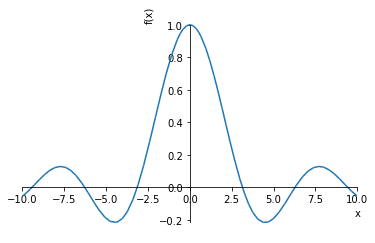

```
<sympy.plotting.plot.Plot at 0x7fac5f8ff6d8>
```

```python
plot(sin(x)/x,(x,-10,10))
```

Несколько функций.

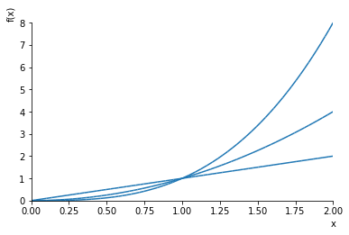

```
<sympy.plotting.plot.Plot at 0x7fac5f567390>
```

```python
plot(x,x**2,x**3,(x,0,2))
```

Другие функции надо импортировать из пакета `sympy.plotting`.

```python
from sympy.plotting import (plot_parametric,plot_implicit,
                            plot3d,plot3d_parametric_line,
                            plot3d_parametric_surface)
```

Параметрический график - фигура Лиссажу.

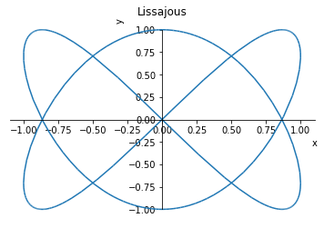

```
<sympy.plotting.plot.Plot at 0x7fac5f514978>
```

```python
t=Symbol('t')
plot_parametric(sin(2*t),cos(3*t),(t,0,2*pi),
                title='Lissajous',xlabel='x',ylabel='y')
```

Неявный график - окружность.

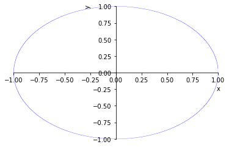

```
<sympy.plotting.plot.Plot at 0x7fac5f625940>
```

```python
plot_implicit(x**2+y**2-1,(x,-1,1),(y,-1,1))
```

Поверхность. Если она строится не `inline`, а в отдельном окне, то её можно вертеть мышкой.

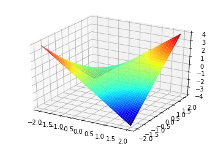

```
<sympy.plotting.plot.Plot at 0x7fac71242ac8>
```

```python
plot3d(x*y,(x,-2,2),(y,-2,2))
```

Несколько поверхностей.

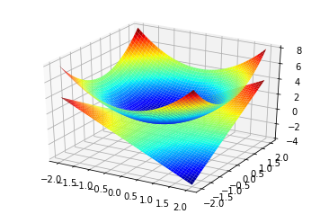

```
<sympy.plotting.plot.Plot at 0x7fac5f3ac9b0>
```

```python
plot3d(x**2+y**2,x*y,(x,-2,2),(y,-2,2))
```

Параметрическая пространственная линия - спираль.

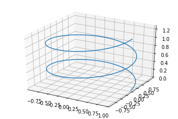

```
<sympy.plotting.plot.Plot at 0x7fac5d25be10>
```

```python
a=0.1
plot3d_parametric_line(cos(t),sin(t),a*t,(t,0,4*pi))
```

Параметрическая поверхность - тор.

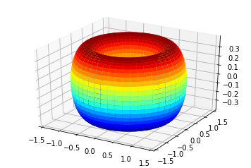

```
<sympy.plotting.plot.Plot at 0x7fac5d151f60>
```

```python
u,v=symbols('u v')
a=0.4
plot3d_parametric_surface((1+a*cos(u))*cos(v),
                          (1+a*cos(u))*sin(v),a*sin(u),
                          (u,0,2*pi),(v,0,2*pi))
```